# Lab 4

Ethan Wanlass

10/24/2019

## Background

An excerpt of the individual player data of the Cyclone football team is available from Canvas. Dowload the excel file and put the file next to your Rmd files.

Some abbreviations for the column names can be found in the Glossaries sheet in the Excel file.

**References:**

- [Iowa State University Athelete](https://cyclones.com/index.aspx)
- [A Beginner’s Guide to American Football](https://www.youtube.com/watch?v=3t6hM5tRlfA) for the rules of American football.

## Loading Data: Cyclone Football

The Cyclone football data involves multiple Excel sheets. The following loads each sheet into a dataframe as well as load the libraries that I will be using.

```r
library(readxl)
library(dplyr)
```

```r
library(tidyr)

defense <- read_excel('cyclonesFootball2018.xlsx', sheet='Defensive')
offense <- read_excel('cyclonesFootball2018.xlsx', sheet='Offensive')
bio <- read_excel('cyclonesFootball2018.xlsx', sheet='Biography')
```

## Cleaning data

The following code will give us a glimpse of what each of the dataframes look like.

```r
head(defense)
```

```
## # A tibble: 6 x 11
##   Name  Opponent_Oppone~ Tackles_Solo Tackles_ASST Tackles_TFL Tackles_Sack
##   <chr> <chr>            <chr>        <chr>        <chr>       <chr>
## 1 Eisw~ Iowa             3            3            0           0
## 2 Eisw~ Oklahoma         6            8            1.0         0
## 3 Eisw~ Akron            7            2            1.0         0
## 4 Eisw~ TCU              6            3            0           0
## 5 Eisw~ Oklahoma State   3            0            1.0         0
## 6 Eisw~ West Virginia    5            3            1.0         1.0
## # ... with 5 more variables: Turnover_FF <chr>, Turnover_FR <chr>,
## #   Turnover_INT <chr>, Pass_QBH <chr>, Pass_PB <chr>
```

```r
head(offense)
```

```
## # A tibble: 6 x 12
##   Name  Opponent_Oppone~ Receiving_REC Receiving_YDS Receiving_TD
##   <chr> <chr>            <chr>         <chr>         <chr>
## 1 Jone~ Iowa             1             31            0
## 2 Jone~ Oklahoma         9             66            0
## 3 Jone~ Akron            6             39            0
## 4 Jone~ TCU              3             23            0
## 5 Jone~ Oklahoma State   6             37            1
## 6 Jone~ West Virginia    1             32            1
## # ... with 7 more variables: Rushing_ATT <chr>, Rushing_YDS <chr>,
## #   Rushing_TD <chr>, `Passing_CMP-ATT` <chr>, Passing_YDS <chr>,
## #   Passing_TD <chr>, Passing_INT <chr>
```

```r
head(bio)
```

```
## # A tibble: 6 x 7
##   Name        Position    Height Weight Class       Hometown     Highschool
##   <chr>       <chr>       <chr>  <chr>  <chr>       <chr>        <chr>
## 1 Akers, Lan~ Wide Recei~ 6-0    192    Redshirt S~ Cedar Rapid~ Washington
## 2 Allen, Cha~ Tight End   6-7    240    Redshirt S~ Nixa, Mo.    Nixa
## 3 Alt, Gerry  Offensive ~ 6-2    290    Redshirt F~ Cedar Rapid~ Washington
## 4 Anderson, ~ Tight End   6-4    250    Redshirt S~ League City~ Clear Fal~
## 5 Assalley, ~ Placekicker 6-0    191    Redshirt S~ Naperville,~ Central
## 6 Austin, Aa~ Linebacker  5-11   205    Redshirt S~ Walnut, Cal~ Bishop Am~
```

The first step to being able to analyze this data is to clean it. To start I factored the names in the dataframes defense, offense and bio. I also factored the opposing team’s name in defense and offense.

```r
defClean = defense
offClean = offense
bioClean = bio

defClean$Name = factor(defClean$Name)
offClean$Name = factor(offClean$Name)
bioClean$Name = factor(bioClean$Name)

defClean$Opponent_Opponent = factor(defClean$Opponent_Opponent)
offClean$Opponent_Opponent = factor(offClean$Opponent_Opponent)
```

Afterwards, I changed the rest of the variables in defense and offense as well as weight as a numeric variable instead of a character variable. Then did a quick check to make sure these columns were now the correct class.

```r
defClean = defClean %>% mutate_at(3:11, as.numeric, na.rm = TRUE)
offClean = offClean %>% mutate_at(3:12, as.numeric, na.rm = TRUE)
bioClean = bioClean %>% mutate_at('Weight', as.numeric, na.rm = TRUE)

class(defClean$Tackles_Solo)
```

```
## [1] "numeric"
```

```r
class(offClean$Rushing_ATT)
```

```
## [1] "numeric"
```

```r
class(bioClean$Weight)
```

```
## [1] "numeric"
```

In order to change the height into a better format, I seperated it into two columns: feet and inches.

```r
bioClean = bioClean %>%
  separate(Height, into = c('Feet', 'Inches'), sep = "-")
bioClean = bioClean %>% mutate_at(c('Feet','Inches'), as.numeric, na.rm = TRUE)
class(bioClean$Feet)
```

```
## [1] "numeric"
```

Finally, I checked to see the structure of each of the cleaned data sets.

```r
str(defClean)
```

```
## Classes 'tbl_df', 'tbl' and 'data.frame':    446 obs. of  11 variables:
##  $ Name             : Factor w/ 42 levels "Akers, Landen",..: 7 7 7 7 7 7 7 7 7 7 ...
##  $ Opponent_Opponent: Factor w/ 13 levels "Akron","Baylor",..: 4 7 1 9 8 13 11 5 2 10 ...
##  $ Tackles_Solo     : num  3 6 7 6 3 5 3 7 2 9 ...
##  $ Tackles_ASST     : num  3 8 2 3 0 3 2 1 4 3 ...
##  $ Tackles_TFL      : num  0 1 1 0 1 1 0 0 0 0 ...
##  $ Tackles_Sack     : num  0 0 0 0 0 1 0 0 0 0 ...
##  $ Turnover_FF      : num  0 1 0 0 0 0 0 0 0 1 ...
##  $ Turnover_FR      : num  0 0 0 0 0 0 0 0 0 0 ...
##  $ Turnover_INT     : num  0 0 0 0 0 0 1 0 0 0 ...
##  $ Pass_QBH         : num  0 0 0 0 0 0 0 0 0 0 ...
##  $ Pass_PB          : num  0 0 3 0 0 0 0 0 0 0 ...
```

```r
str(offClean)
```

```
## Classes 'tbl_df', 'tbl' and 'data.frame':    168 obs. of  12 variables:
##  $ Name             : Factor w/ 15 levels "Akers, Landen",..: 6 6 6 6 6 6 6 6 6 6 ...
##  $ Opponent_Opponent: Factor w/ 13 levels "Akron","Baylor",..: 4 7 1 9 8 13 11 5 2 10 ...
##  $ Receiving_REC    : num  1 9 6 3 6 1 1 4 4 0 ...
##  $ Receiving_YDS    : num  31 66 39 23 37 32 4 31 39 0 ...
##  $ Receiving_TD     : num  0 0 0 0 1 1 0 0 1 0 ...
##  $ Rushing_ATT      : num  NA NA NA NA NA NA NA NA NA NA ...
##  $ Rushing_YDS      : num  NA NA NA NA NA NA NA NA NA NA ...
##  $ Rushing_TD       : num  NA NA NA NA NA NA NA NA NA NA ...
##  $ Passing_CMP-ATT  : num  NA NA NA NA NA NA NA NA NA NA ...
##  $ Passing_YDS      : num  NA NA NA NA NA NA NA NA NA NA ...
##  $ Passing_TD       : num  NA NA NA NA NA NA NA NA NA NA ...
##  $ Passing_INT      : num  NA NA NA NA NA NA NA NA NA NA ...
```

```r
str(bioClean)
```

```
## Classes 'tbl_df', 'tbl' and 'data.frame':    123 obs. of  8 variables:
##  $ Name      : Factor w/ 123 levels "Akers, Landen",..: 1 2 3 4 5 6 7 8 9 10 ...
##  $ Position  : chr  "Wide Receiver" "Tight End" "Offensive Line" "Tight End" ...
##  $ Feet      : num  6 6 6 6 6 5 6 6 6 6 ...
##  $ Inches    : num  0 7 2 4 0 11 0 3 2 2 ...
##  $ Weight    : num  192 240 290 250 191 205 192 224 251 284 ...
##  $ Class     : chr  "Redshirt Sophomore" "Redshirt Sophomore" "Redshirt Freshman" "Redshirt Senior" ...
##  $ Hometown  : chr  "Cedar Rapids, Iowa" "Nixa, Mo." "Cedar Rapids, Iowa" "League City, Texas" ...
##  $ Highschool: chr  "Washington" "Nixa" "Washington" "Clear Falls" ...
```

## Tidying Defense

First thing I did was tidy the columns into statistic types and the amount each player made.

```r
defClean = defClean %>% gather(key=Statistic, value=Amount, 3:11)
defClean
```

```
## # A tibble: 4,014 x 4
##    Name           Opponent_Opponent Statistic    Amount
##    <fct>          <fct>             <chr>         <dbl>
##  1 Eisworth, Greg Iowa              Tackles_Solo      3
##  2 Eisworth, Greg Oklahoma          Tackles_Solo      6
##  3 Eisworth, Greg Akron             Tackles_Solo      7
##  4 Eisworth, Greg TCU               Tackles_Solo      6
##  5 Eisworth, Greg Oklahoma State    Tackles_Solo      3
##  6 Eisworth, Greg West Virginia     Tackles_Solo      5
##  7 Eisworth, Greg Texas Tech        Tackles_Solo      3
##  8 Eisworth, Greg Kansas            Tackles_Solo      7
##  9 Eisworth, Greg Baylor            Tackles_Solo      2
## 10 Eisworth, Greg Texas             Tackles_Solo      9
## # ... with 4,004 more rows
```

The following will display a histogram of each defensive statistic:

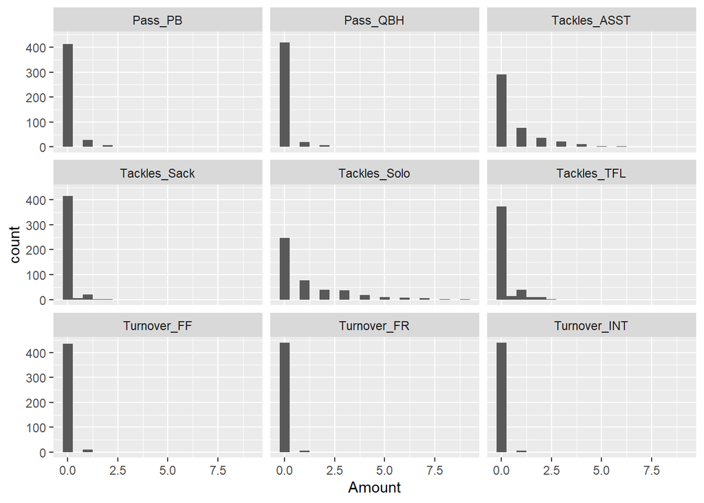

```r
library(ggplot2)
ggplot(defClean, aes(Amount)) + facet_wrap(~Statistic) + geom_histogram(binwidth = .5)
```

Looking at these histograms we can see that Sacks, QB hurries, Passes blocked and Turnovers are rarer defensive stats.

Next, let’s show the defensive performance between two specific games: West Virginia and Kansas State. We will base defensive performance on the number of solo tackles by each player. The larger number of solo tackes means a better performance.

```r
solo_tackles = defClean %>%
  filter(Statistic == 'Tackles_Solo')
spreaded = solo_tackles %>% spread(key=Opponent_Opponent, value=Amount)
class(spreaded$`West Virginia`)
```

```
## [1] "numeric"
```

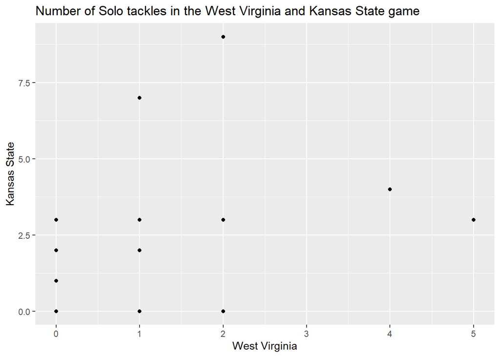

```r
colnames(spreaded)[colnames(spreaded)=="West Virginia"] <- "West_Virginia"
colnames(spreaded)[colnames(spreaded)=="Kansas State"] <- "Kansas_State"
ggplot(spreaded, aes(West_Virginia,Kansas_State), na.rm = TRUE) + geom_point() + labs(title = 'Number of Solo tackles in the West Virginia and Kansas State game', x = 'West Virginia', y = 'Kansas State')
```

Looking at the scatterplot, there appears to be have been a slightly better defensive performance in the Kansas State game.

## Tidying Bio (B)

Now let’s turn our attention to the player biography `bioClean`.

Let’s seperate the column hometown into 2 columns: city and State

```r
bioClean = bioClean %>%
  separate(Hometown, into = c('City', 'State'), sep = ",")
bioClean
```

```
## # A tibble: 123 x 9
##    Name     Position    Feet Inches Weight Class    City   State Highschool
##    <fct>    <chr>      <dbl>  <dbl>  <dbl> <chr>    <chr>  <chr> <chr>
##  1 Akers, ~ Wide Rece~     6      0    192 Redshir~ Cedar~ " Io~ Washington
##  2 Allen, ~ Tight End      6      7    240 Redshir~ Nixa   " Mo~ Nixa
##  3 Alt, Ge~ Offensive~     6      2    290 Redshir~ Cedar~ " Io~ Washington
##  4 Anderso~ Tight End      6      4    250 Redshir~ Leagu~ " Te~ Clear Fal~
##  5 Assalle~ Placekick~     6      0    191 Redshir~ Naper~ " Il~ Central
##  6 Austin,~ Linebacker     5     11    205 Redshir~ Walnut " Ca~ Bishop Am~
##  7 Azunna,~ Defensive~     6      0    192 Redshir~ Grand~ " Te~ Lake Ridge
##  8 Bailey,~ Defensive~     6      3    224 Redshir~ Clark~ " Mi~ Clarksdale
##  9 Bailey,~ Defensive~     6      2    251 Junior   Jacks~ " Fl~ Raines
## 10 Bailey,~ Defensive~     6      2    284 Redshir~ Jacks~ " Fl~ Raines
## # ... with 113 more rows
```

From there we can check the count of total players from each state.

```r
bioClean %>% group_by(State) %>% summarize(Number=n())
```

```
## # A tibble: 25 x 2
##    State        Number
##    <chr>         <int>
##  1 " Ariz."          3
##  2 " Ark."           2
##  3 " Australia"      2
##  4 " Calif."         8
##  5 " D.C."           1
##  6 " Fla."           8
##  7 " Ga."            2
##  8 " Ill."           5
##  9 " Iowa"          44
## 10 " Kan."           3
## # ... with 15 more rows
```

## Joining DataFrames

Let’s take a look at where each offensive player is from. To do so we combined the offense and bio data frames into a new dataframe and then grouped by player to see their hometowns.

```r
joint = left_join(offense,bio,by = "Name")
joint%>% group_by(Name) %>% summarize(hometown = unique(Hometown))
```

```
## # A tibble: 15 x 2
##    Name              hometown
##    <chr>             <chr>
##  1 Akers, Landen     Cedar Rapids, Iowa
##  2 Allen, Chase      Nixa, Mo.
##  3 Butler, Hakeem    Baltimore, Md.
##  4 Eaton, Matthew    Norfolk, Va.
##  5 Johnson, Josh     Little Rock, Ark.
##  6 Jones, Deshaunte  Cincinnati, Ohio
##  7 Kempt, Kyle       Massillon, Ohio
##  8 Kolar, Charlie    Norman, Okla.
##  9 Lang, Johnnie     Palmetto, Fla.
## 10 Milton, Tarique   Bradenton, Fla.
## 11 Montgomery, David Cincinnati, Ohio
## 12 Noland, Zeb       <NA>
## 13 Nwangwu, Kene     Frisco, Texas
## 14 Purdy, Brock      Gilbert, Ariz.
## 15 Seonbuchner, Sam  Oconomowoc, Wis.
```

```r
joint$Weight = factor(joint$Weight)
joint$Receiving_YDS = as.numeric(joint$Receiving_YDS)

str(joint)
```

```
## Classes 'tbl_df', 'tbl' and 'data.frame':    168 obs. of  18 variables:
##  $ Name             : chr  "Jones, Deshaunte" "Jones, Deshaunte" "Jones, Deshaunte" "Jones, Deshaunte" ...
##  $ Opponent_Opponent: chr  "Iowa" "Oklahoma" "Akron" "TCU" ...
##  $ Receiving_REC    : chr  "1" "9" "6" "3" ...
##  $ Receiving_YDS    : num  31 66 39 23 37 32 4 31 39 0 ...
##  $ Receiving_TD     : chr  "0" "0" "0" "0" ...
##  $ Rushing_ATT      : chr  NA NA NA NA ...
##  $ Rushing_YDS      : chr  NA NA NA NA ...
##  $ Rushing_TD       : chr  NA NA NA NA ...
##  $ Passing_CMP-ATT  : chr  NA NA NA NA ...
##  $ Passing_YDS      : chr  NA NA NA NA ...
##  $ Passing_TD       : chr  NA NA NA NA ...
##  $ Passing_INT      : chr  NA NA NA NA ...
##  $ Position         : chr  "Wide Receiver" "Wide Receiver" "Wide Receiver" "Wide Receiver" ...
##  $ Height           : chr  "5-10" "5-10" "5-10" "5-10" ...
##  $ Weight           : Factor w/ 14 levels "176","183","185",..: 3 3 3 3 3 3 3 3 3 3 ...
##  $ Class            : chr  "Junior" "Junior" "Junior" "Junior" ...
##  $ Hometown         : chr  "Cincinnati, Ohio" "Cincinnati, Ohio" "Cincinnati, Ohio" "Cincinnati, Ohio" ...
##  $ Highschool       : chr  "Colerain" "Colerain" "Colerain" "Colerain" ...
```

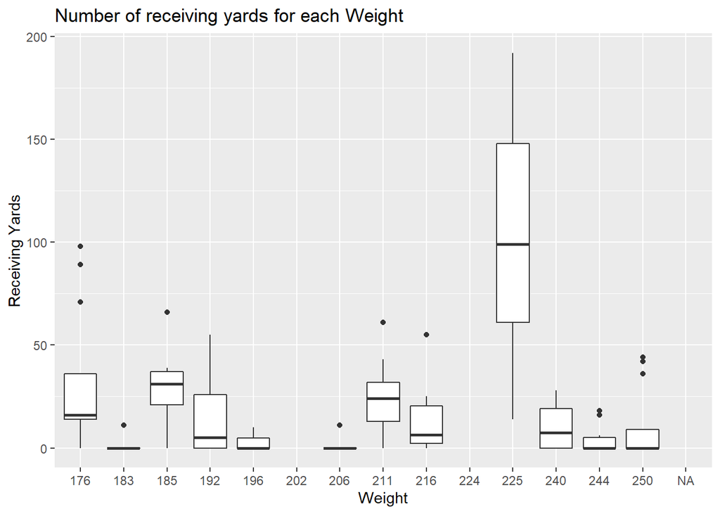

```r
ggplot(joint, aes(Weight,Receiving_YDS)) + geom_boxplot() + labs(title = 'Number of receiving yards for each Weight', x = 'Weight', y = 'Receiving Yards')
```

Looking at these boxplots, weight does not seem to have much impact on the amount of receiving yards. The large differences are probably from individual players.

3. Explore more. Raise a question that can be answered only by looking at two or more data frames. Then answer that question.

Is there a relationship between the class and the number of touchdown receptions?

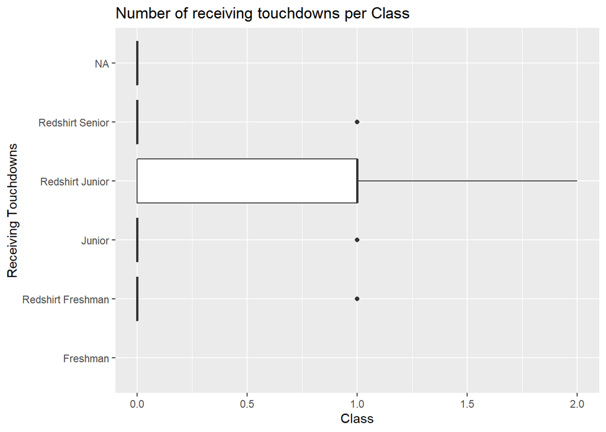

```r
joint$Class = factor(joint$Class, levels = c('Freshman', 'Redshirt Freshman', 'Sophmore', 'Redshirt Sophmore', 'Junior', 'Redshirt Junior', 'Senior', 'Redshirt Senior'))

joint$Receiving_TD = as.numeric(joint$Receiving_TD)
ggplot(joint, aes(Class, Receiving_TD)) + geom_boxplot() + coord_flip() + labs(title = 'Number of receiving touchdowns per Class', x = 'Receiving Touchdowns', y = 'Class')
```

Looking at this boxplot we can see that outside of Redshirt juniors, there were very little touchdown receptions from the Iowa State Offense.